| Technological Institute of the Philippines | Quezon City - Computer Engineering |
| --- | --- |
| Course Code: | CPE 019 |
| Code Title: | Emerging Technologies in CpE 2 |
| Summer | AY 2024 - 2025 |
| **Hands-on Activity 4.1** | **Advanced Data Analytics and Machine Learning** |
| **Name** | Calvadores, Kelly Joseph |
| **Section** | CPE32S1 |
| **Date Performed**: | June 19, 2024 |
| **Date Submitted**: | June 20, 2024 |
| **Instructor**: | Engr. Roman M. Richard |

# PART A: Do the following objectives:

## Part 1: Import the Libraries and Data

```python
import pandas as pd
import numpy as np
import matplotlib.pyplot as plt
import seaborn as sns

TrainData = pd.read_csv('/content/drive/MyDrive/CPE 019 (Retake)/HOA 4.1/titanic_train.csv')
TestData = pd.read_csv('/content/drive/MyDrive/CPE 019 (Retake)/HOA 4.1/titanic_test.csv')
TrainData
```

|  | PassengerId | Survived | Pclass | Name | Sex | Age | SibSp | Parch | Ticket | Fare | Cabin | Embarked |
| --- | --- | --- | --- | --- | --- | --- | --- | --- | --- | --- | --- | --- |
| 0 | 1 | 0 | 3 | Braund, Mr. Owen Harris | male | 22.0 | 1 | 0 | A/5 21171 | 7.2500 | NaN | S |
| 1 | 2 | 1 | 1 | Cumings, Mrs. John Bradley (Florence Briggs Th... | female | 38.0 | 1 | 0 | PC 17599 | 71.2833 | C85 | C |
| 2 | 3 | 1 | 3 | Heikkinen, Miss. Laina | female | 26.0 | 0 | 0 | STON/O2. 3101282 | 7.9250 | NaN | S |
| 3 | 4 | 1 | 1 | Futrelle, Mrs. Jacques Heath (Lily May Peel) | female | 35.0 | 1 | 0 | 113803 | 53.1000 | C123 | S |
| 4 | 5 | 0 | 3 | Allen, Mr. William Henry | male | 35.0 | 0 | 0 | 373450 | 8.0500 | NaN | S |
| ... | ... | ... | ... | ... | ... | ... | ... | ... | ... | ... | ... | ... |
| 886 | 887 | 0 | 2 | Montvila, Rev. Juozas | male | 27.0 | 0 | 0 | 211536 | 13.0000 | NaN | S |
| 887 | 888 | 1 | 1 | Graham, Miss. Margaret Edith | female | 19.0 | 0 | 0 | 112053 | 30.0000 | B42 | S |
| 888 | 889 | 0 | 3 | Johnston, Miss. Catherine Helen "Carrie" | female | NaN | 1 | 2 | W./C. 6607 | 23.4500 | NaN | S |
| 889 | 890 | 1 | 1 | Behr, Mr. Karl Howell | male | 26.0 | 0 | 0 | 111369 | 30.0000 | C148 | C |
| 890 | 891 | 0 | 3 | Dooley, Mr. Patrick | male | 32.0 | 0 | 0 | 370376 | 7.7500 | NaN | Q |

891 rows × 12 columns

```python
TestData
```

|  | PassengerId | Pclass | Name | Sex | Age | SibSp | Parch | Ticket | Fare | Cabin | Embarked |
| --- | --- | --- | --- | --- | --- | --- | --- | --- | --- | --- | --- |
| 0 | 892 | 3 | Kelly, Mr. James | male | 34.5 | 0 | 0 | 330911 | 7.8292 | NaN | Q |
| 1 | 893 | 3 | Wilkes, Mrs. James (Ellen Needs) | female | 47.0 | 1 | 0 | 363272 | 7.0000 | NaN | S |
| 2 | 894 | 2 | Myles, Mr. Thomas Francis | male | 62.0 | 0 | 0 | 240276 | 9.6875 | NaN | Q |
| 3 | 895 | 3 | Wirz, Mr. Albert | male | 27.0 | 0 | 0 | 315154 | 8.6625 | NaN | S |
| 4 | 896 | 3 | Hirvonen, Mrs. Alexander (Helga E Lindqvist) | female | 22.0 | 1 | 1 | 3101298 | 12.2875 | NaN | S |
| ... | ... | ... | ... | ... | ... | ... | ... | ... | ... | ... | ... |
| 413 | 1305 | 3 | Spector, Mr. Woolf | male | NaN | 0 | 0 | A.5. 3236 | 8.0500 | NaN | S |
| 414 | 1306 | 1 | Oliva y Ocana, Dona. Fermina | female | 39.0 | 0 | 0 | PC 17758 | 108.9000 | C105 | C |
| 415 | 1307 | 3 | Saether, Mr. Simon Sivertsen | male | 38.5 | 0 | 0 | SOTON/O.Q. 3101262 | 7.2500 | NaN | S |
| 416 | 1308 | 3 | Ware, Mr. Frederick | male | NaN | 0 | 0 | 359309 | 8.0500 | NaN | S |
| 417 | 1309 | 3 | Peter, Master. Michael J | male | NaN | 1 | 1 | 2668 | 22.3583 | NaN | C |

418 rows × 11 columns

## Part 2: Plot the Data

```python
TrainData.info()
```

```
<class 'pandas.core.frame.DataFrame'>
RangeIndex: 891 entries, 0 to 890
Data columns (total 12 columns):
 #   Column       Non-Null Count  Dtype
---  ------       --------------  -----
 0   PassengerId  891 non-null    int64
 1   Survived     891 non-null    int64
 2   Pclass       891 non-null    int64
 3   Name         891 non-null    object
 4   Sex          891 non-null    object
 5   Age          714 non-null    float64
 6   SibSp        891 non-null    int64
 7   Parch        891 non-null    int64
 8   Ticket       891 non-null    object
 9   Fare         891 non-null    float64
 10  Cabin        204 non-null    object
 11  Embarked     889 non-null    object
dtypes: float64(2), int64(5), object(5)
memory usage: 83.7+ KB
```

```python
TestData.info()
```

```
<class 'pandas.core.frame.DataFrame'>
RangeIndex: 418 entries, 0 to 417
Data columns (total 11 columns):
 #   Column       Non-Null Count  Dtype
---  ------       --------------  -----
 0   PassengerId  418 non-null    int64
 1   Pclass       418 non-null    int64
 2   Name         418 non-null    object
 3   Sex          418 non-null    object
 4   Age          332 non-null    float64
 5   SibSp        418 non-null    int64
 6   Parch        418 non-null    int64
 7   Ticket       418 non-null    object
 8   Fare         417 non-null    float64
 9   Cabin        91 non-null     object
 10  Embarked     418 non-null    object
dtypes: float64(2), int64(4), object(5)
memory usage: 36.0+ KB
```

```python
TrainData.isnull().sum()
```

```
PassengerId      0
Survived         0
Pclass           0
Name             0
Sex              0
Age            177
SibSp            0
Parch            0
Ticket           0
Fare             0
Cabin          687
Embarked         2
dtype: int64
```

```python
TestData.isnull().sum()
```

```
PassengerId      0
Pclass           0
Name             0
Sex              0
Age             86
SibSp            0
Parch            0
Ticket           0
Fare             1
Cabin          327
Embarked         0
dtype: int64
```

```python
from sklearn.preprocessing import LabelEncoder
LE = LabelEncoder()
for col in TrainData.columns:
  if TrainData[col].dtype == 'object':
    TrainData[col] = LE.fit_transform(TrainData[col])
  else:
    pass
TrainData.info()
```

```
<class 'pandas.core.frame.DataFrame'>
RangeIndex: 891 entries, 0 to 890
Data columns (total 12 columns):
 #   Column       Non-Null Count  Dtype
---  ------       --------------  -----
 0   PassengerId  891 non-null    int64
 1   Survived     891 non-null    int64
 2   Pclass       891 non-null    int64
 3   Name         891 non-null    int64
 4   Sex          891 non-null    int64
 5   Age          714 non-null    float64
 6   SibSp        891 non-null    int64
 7   Parch        891 non-null    int64
 8   Ticket       891 non-null    int64
 9   Fare         891 non-null    float64
 10  Cabin        891 non-null    int64
 11  Embarked     891 non-null    int64
dtypes: float64(2), int64(10)
memory usage: 83.7 KB
```

```python
for col in TestData.columns:
  if TestData[col].dtype == 'object':
    TestData[col] = LE.fit_transform(TestData[col])
  else:
    pass
TestData.info()
```

```
<class 'pandas.core.frame.DataFrame'>
RangeIndex: 418 entries, 0 to 417
Data columns (total 11 columns):
 #   Column       Non-Null Count  Dtype
---  ------       --------------  -----
 0   PassengerId  418 non-null    int64
 1   Pclass       418 non-null    int64
 2   Name         418 non-null    int64
 3   Sex          418 non-null    int64
 4   Age          332 non-null    float64
 5   SibSp        418 non-null    int64
 6   Parch        418 non-null    int64
 7   Ticket       418 non-null    int64
 8   Fare         417 non-null    float64
 9   Cabin        418 non-null    int64
 10  Embarked     418 non-null    int64
dtypes: float64(2), int64(9)
memory usage: 36.0 KB
```

```python
TrainData.isnull().sum()
```

```
PassengerId      0
Survived         0
Pclass           0
Name             0
Sex              0
Age            177
SibSp            0
Parch            0
Ticket           0
Fare             0
Cabin            0
Embarked         0
dtype: int64
```

```python
TestData.isnull().sum()
```

```
PassengerId     0
Pclass          0
Name            0
Sex             0
Age            86
SibSp           0
Parch           0
Ticket          0
Fare            1
Cabin           0
Embarked        0
dtype: int64
```

```python
TrainData
```

|  | PassengerId | Survived | Pclass | Name | Sex | Age | SibSp | Parch | Ticket | Fare | Cabin | Embarked |
| --- | --- | --- | --- | --- | --- | --- | --- | --- | --- | --- | --- | --- |
| 0 | 1 | 0 | 3 | 108 | 1 | 22.0 | 1 | 0 | 523 | 7.2500 | 147 | 2 |
| 1 | 2 | 1 | 1 | 190 | 0 | 38.0 | 1 | 0 | 596 | 71.2833 | 81 | 0 |
| 2 | 3 | 1 | 3 | 353 | 0 | 26.0 | 0 | 0 | 669 | 7.9250 | 147 | 2 |
| 3 | 4 | 1 | 1 | 272 | 0 | 35.0 | 1 | 0 | 49 | 53.1000 | 55 | 2 |
| 4 | 5 | 0 | 3 | 15 | 1 | 35.0 | 0 | 0 | 472 | 8.0500 | 147 | 2 |
| ... | ... | ... | ... | ... | ... | ... | ... | ... | ... | ... | ... | ... |
| 886 | 887 | 0 | 2 | 548 | 1 | 27.0 | 0 | 0 | 101 | 13.0000 | 147 | 2 |
| 887 | 888 | 1 | 1 | 303 | 0 | 19.0 | 0 | 0 | 14 | 30.0000 | 30 | 2 |
| 888 | 889 | 0 | 3 | 413 | 0 | NaN | 1 | 2 | 675 | 23.4500 | 147 | 2 |
| 889 | 890 | 1 | 1 | 81 | 1 | 26.0 | 0 | 0 | 8 | 30.0000 | 60 | 0 |
| 890 | 891 | 0 | 3 | 220 | 1 | 32.0 | 0 | 0 | 466 | 7.7500 | 147 | 1 |

891 rows × 12 columns

```python
TestData
```

|  | PassengerId | Pclass | Name | Sex | Age | SibSp | Parch | Ticket | Fare | Cabin | Embarked |
| --- | --- | --- | --- | --- | --- | --- | --- | --- | --- | --- | --- |
| 0 | 892 | 3 | 206 | 1 | 34.5 | 0 | 0 | 152 | 7.8292 | 76 | 1 |
| 1 | 893 | 3 | 403 | 0 | 47.0 | 1 | 0 | 221 | 7.0000 | 76 | 2 |
| 2 | 894 | 2 | 269 | 1 | 62.0 | 0 | 0 | 73 | 9.6875 | 76 | 1 |
| 3 | 895 | 3 | 408 | 1 | 27.0 | 0 | 0 | 147 | 8.6625 | 76 | 2 |
| 4 | 896 | 3 | 178 | 0 | 22.0 | 1 | 1 | 138 | 12.2875 | 76 | 2 |
| ... | ... | ... | ... | ... | ... | ... | ... | ... | ... | ... | ... |
| 413 | 1305 | 3 | 353 | 1 | NaN | 0 | 0 | 267 | 8.0500 | 76 | 2 |
| 414 | 1306 | 1 | 283 | 0 | 39.0 | 0 | 0 | 324 | 108.9000 | 22 | 0 |
| 415 | 1307 | 3 | 332 | 1 | 38.5 | 0 | 0 | 346 | 7.2500 | 76 | 2 |
| 416 | 1308 | 3 | 384 | 1 | NaN | 0 | 0 | 220 | 8.0500 | 76 | 2 |
| 417 | 1309 | 3 | 302 | 1 | NaN | 1 | 1 | 105 | 22.3583 | 76 | 0 |

418 rows × 11 columns

```python
TrainData = TrainData.fillna(TrainData.mean())
TrainData.info()
```

```
<class 'pandas.core.frame.DataFrame'>
RangeIndex: 891 entries, 0 to 890
Data columns (total 12 columns):
 #   Column       Non-Null Count  Dtype
---  ------       --------------  -----
 0   PassengerId  891 non-null    int64
 1   Survived     891 non-null    int64
 2   Pclass       891 non-null    int64
 3   Name         891 non-null    int64
 4   Sex          891 non-null    int64
 5   Age          891 non-null    float64
 6   SibSp        891 non-null    int64
 7   Parch        891 non-null    int64
 8   Ticket       891 non-null    int64
 9   Fare         891 non-null    float64
 10  Cabin        891 non-null    int64
 11  Embarked     891 non-null    int64
dtypes: float64(2), int64(10)
memory usage: 83.7 KB
```

```python
TestData = TestData.fillna(TestData.mean())
TestData.info()
```

```
<class 'pandas.core.frame.DataFrame'>
RangeIndex: 418 entries, 0 to 417
Data columns (total 11 columns):
 #   Column       Non-Null Count  Dtype
---  ------       --------------  -----
 0   PassengerId  418 non-null    int64
 1   Pclass       418 non-null    int64
 2   Name         418 non-null    int64
 3   Sex          418 non-null    int64
 4   Age          418 non-null    float64
 5   SibSp        418 non-null    int64
 6   Parch        418 non-null    int64
 7   Ticket       418 non-null    int64
 8   Fare         418 non-null    float64
 9   Cabin        418 non-null    int64
 10  Embarked     418 non-null    int64
dtypes: float64(2), int64(9)
memory usage: 36.0 KB
```

```python
TrainData.isnull().sum()
```

```
PassengerId    0
Survived       0
Pclass         0
Name           0
Sex            0
Age            0
SibSp          0
Parch          0
Ticket         0
Fare           0
Cabin          0
Embarked       0
dtype: int64
```

```python
TestData.isnull().sum()
```

```
PassengerId    0
Pclass         0
Name           0
Sex            0
Age            0
SibSp          0
Parch          0
Ticket         0
Fare           0
Cabin          0
Embarked       0
dtype: int64
```

```python
TrainData
```

|  | PassengerId | Survived | Pclass | Name | Sex | Age | SibSp | Parch | Ticket | Fare | Cabin | Embarked |
| --- | --- | --- | --- | --- | --- | --- | --- | --- | --- | --- | --- | --- |
| 0 | 1 | 0 | 3 | 108 | 1 | 22.000000 | 1 | 0 | 523 | 7.2500 | 147 | 2 |
| 1 | 2 | 1 | 1 | 190 | 0 | 38.000000 | 1 | 0 | 596 | 71.2833 | 81 | 0 |
| 2 | 3 | 1 | 3 | 353 | 0 | 26.000000 | 0 | 0 | 669 | 7.9250 | 147 | 2 |
| 3 | 4 | 1 | 1 | 272 | 0 | 35.000000 | 1 | 0 | 49 | 53.1000 | 55 | 2 |
| 4 | 5 | 0 | 3 | 15 | 1 | 35.000000 | 0 | 0 | 472 | 8.0500 | 147 | 2 |
| ... | ... | ... | ... | ... | ... | ... | ... | ... | ... | ... | ... | ... |
| 886 | 887 | 0 | 2 | 548 | 1 | 27.000000 | 0 | 0 | 101 | 13.0000 | 147 | 2 |
| 887 | 888 | 1 | 1 | 303 | 0 | 19.000000 | 0 | 0 | 14 | 30.0000 | 30 | 2 |
| 888 | 889 | 0 | 3 | 413 | 0 | 29.699118 | 1 | 2 | 675 | 23.4500 | 147 | 2 |
| 889 | 890 | 1 | 1 | 81 | 1 | 26.000000 | 0 | 0 | 8 | 30.0000 | 60 | 0 |
| 890 | 891 | 0 | 3 | 220 | 1 | 32.000000 | 0 | 0 | 466 | 7.7500 | 147 | 1 |

891 rows × 12 columns

```python
TestData
```

|  | PassengerId | Pclass | Name | Sex | Age | SibSp | Parch | Ticket | Fare | Cabin | Embarked |
| --- | --- | --- | --- | --- | --- | --- | --- | --- | --- | --- | --- |
| 0 | 892 | 3 | 206 | 1 | 34.50000 | 0 | 0 | 152 | 7.8292 | 76 | 1 |
| 1 | 893 | 3 | 403 | 0 | 47.00000 | 1 | 0 | 221 | 7.0000 | 76 | 2 |
| 2 | 894 | 2 | 269 | 1 | 62.00000 | 0 | 0 | 73 | 9.6875 | 76 | 1 |
| 3 | 895 | 3 | 408 | 1 | 27.00000 | 0 | 0 | 147 | 8.6625 | 76 | 2 |
| 4 | 896 | 3 | 178 | 0 | 22.00000 | 1 | 1 | 138 | 12.2875 | 76 | 2 |
| ... | ... | ... | ... | ... | ... | ... | ... | ... | ... | ... | ... |
| 413 | 1305 | 3 | 353 | 1 | 30.27259 | 0 | 0 | 267 | 8.0500 | 76 | 2 |
| 414 | 1306 | 1 | 283 | 0 | 39.00000 | 0 | 0 | 324 | 108.9000 | 22 | 0 |
| 415 | 1307 | 3 | 332 | 1 | 38.50000 | 0 | 0 | 346 | 7.2500 | 76 | 2 |
| 416 | 1308 | 3 | 384 | 1 | 30.27259 | 0 | 0 | 220 | 8.0500 | 76 | 2 |
| 417 | 1309 | 3 | 302 | 1 | 30.27259 | 1 | 1 | 105 | 22.3583 | 76 | 0 |

418 rows × 11 columns

### Titanic_Train

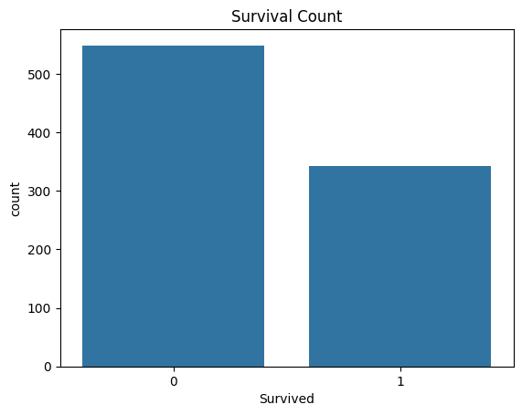

```python
sns.countplot(data=TrainData, x='Survived')
plt.title('Survival Count')
plt.show()
```

```python
Survived = TrainData["Survived"].value_counts()
Total = len(TrainData)
survived_percentages = (Survived / Total) * 100
print(survived_percentages)
```

```
Survived
0    61.616162
1    38.383838
Name: count, dtype: float64
```

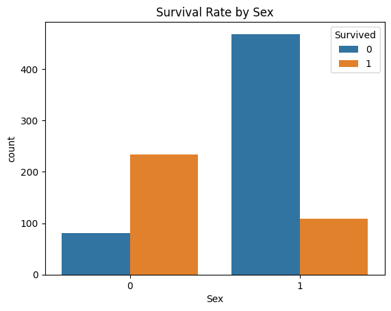

```python
sns.countplot(data=TrainData, x='Sex', hue='Survived')
plt.title('Survival Rate by Sex')
plt.show()
```

```python
sex_survival_counts = TrainData.groupby(['Sex', 'Survived']).size().unstack()
sex_survival_rate = sex_survival_counts.div(sex_survival_counts.sum(axis=1), axis=0) * 100
print(sex_survival_rate)
```

```
Survived          0          1
Sex
0         25.796178  74.203822
1         81.109185  18.890815
```

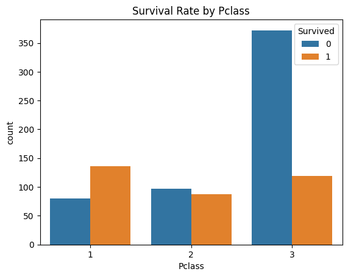

```python
sns.countplot(data=TrainData, x='Pclass', hue='Survived')
plt.title('Survival Rate by Pclass')
```

```python
Pclass_survival_counts = TrainData.groupby(['Pclass', 'Survived']).size().unstack()
Pclass_survival_rate = Pclass_survival_counts.div(Pclass_survival_counts.sum(axis=1), axis=0) * 100
print(Pclass_survival_rate)
```

```
Survived          0          1
Pclass
1         37.037037  62.962963
2         52.717391  47.282609
3         75.763747  24.236253
```

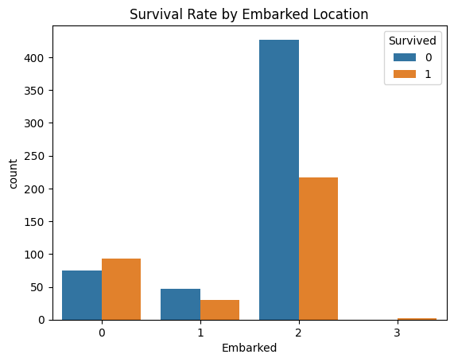

```python
sns.countplot(data=TrainData, x='Embarked', hue='Survived')
plt.title('Survival Rate by Embarked Location')
```

```python
Embarked_survival_counts = TrainData.groupby(['Embarked', 'Survived']).size().unstack()
Embarked_survival_rate = Embarked_survival_counts.div(Embarked_survival_counts.sum(axis=1), axis=0) * 100
print(Embarked_survival_rate)
```

```
Survived          0           1
Embarked
0         44.642857   55.357143
1         61.038961   38.961039
2         66.304348   33.695652
3               NaN  100.000000
```

### Titanic_Test

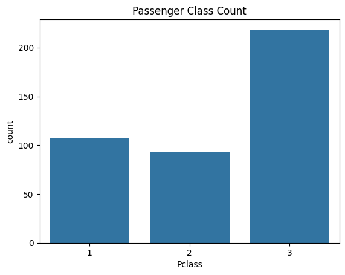

```python
sns.countplot(data=TestData, x='Pclass')
plt.title('Passenger Class Count')
plt.show()
```

```python
Passenger_Class = TestData["Pclass"].value_counts()
Total = len(TestData)
Pclass_percentages = (Passenger_Class / Total) * 100
print(Pclass_percentages)
```

```
Pclass
3    52.153110
1    25.598086
2    22.248804
Name: count, dtype: float64
```

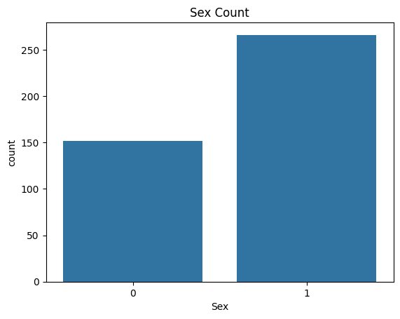

```python
sns.countplot(data=TestData, x='Sex')
plt.title('Sex Count')
plt.show()
```

```python
Sex = TestData["Sex"].value_counts()
Sex_percentages = (Sex / Total) * 100
print(Sex_percentages)
```

```
Sex
1    63.636364
0    36.363636
Name: count, dtype: float64
```

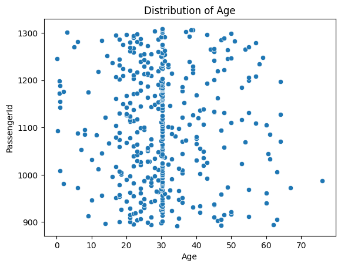

```python
sns.scatterplot(data=TestData, x = 'Age', y = 'PassengerId')
plt.title('Distribution of Age')
plt.show()
```

```python
Age = TestData["Age"].value_counts()
Age_percentages = (Age / Total) * 100
print(Age_percentages)
```

```
Age
30.27259    20.574163
24.00000     4.066986
21.00000     4.066986
22.00000     3.827751
30.00000     3.588517
              ...
76.00000     0.239234
28.50000     0.239234
22.50000     0.239234
62.00000     0.239234
38.50000     0.239234
Name: count, Length: 80, dtype: float64
```

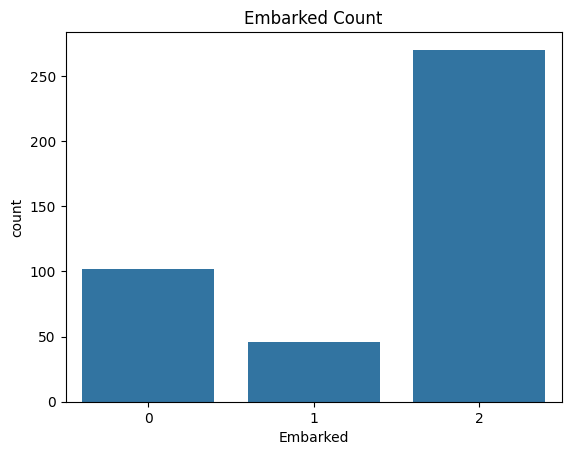

```python
sns.countplot(data=TestData, x='Embarked')
plt.title('Embarked Count')
plt.show()
```

```python
Embarked = TestData["Embarked"].value_counts()
Embarked_percentages = (Embarked / Total) * 100
print(Embarked_percentages)
```

```
Embarked
2    64.593301
0    24.401914
1    11.004785
Name: count, dtype: float64
```

## Part 3: Perform Simple Linear Regression on the SURVIVAL feature column (you can check the internet on how you can perform simple linear regression)

```python
X = TrainData[['Age']]
y = TrainData['Survived']
```

```python
from sklearn.model_selection import train_test_split
from sklearn.linear_model import LinearRegression
from sklearn.metrics import mean_squared_error, r2_score

X_train, X_test, y_train, y_test = train_test_split(X, y, test_size=0.2, random_state=123)
```

```python
Model = LinearRegression()
Model.fit(X_train, y_train)
```

```
LinearRegression()
```

```python
YpredTrain = Model.predict(X_train)
YpredTest = Model.predict(X_test)
```

```python
mse_train = mean_squared_error(y_train, YpredTrain)*100
mse_test = mean_squared_error(y_test, YpredTest)*100
r2_train = r2_score(y_train, YpredTrain)*100
r2_test = r2_score(y_test, YpredTest)*100

print(f'Train Mean Squared Error: {mse_train}')
print(f'Test Mean Squared Error: {mse_test}')
print(f'Train R^2 Score: {r2_train}')
print(f'Test R^2 Score: {r2_test}')
```

```
Train Mean Squared Error: 23.590310313930825
Test Mean Squared Error: 23.374300972588216
Train R^2 Score: 0.751348422877729
Test R^2 Score: -1.0709821137245612
```

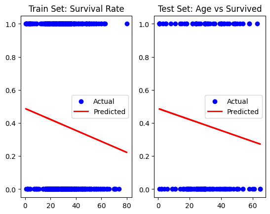

```python
plt.subplot(1, 2, 1)
plt.scatter(X_train, y_train, color='blue', label='Actual')
plt.plot(X_train, YpredTrain, color='red', linewidth=2, label='Predicted')
plt.title('Train Set: Survival Rate')
plt.legend()

plt.subplot(1, 2, 2)
plt.scatter(X_test, y_test, color='blue', label='Actual')
plt.plot(X_test, YpredTest, color='red', linewidth=2, label='Predicted')
plt.title('Test Set: Age vs Survived')
plt.legend()

plt.show()
```

# PART 2: Download this PDF and perform the DECISION TREE classification activity

## Part 1: Create a Decision Tree Classifier

With the data above, what kinds of questions can we ask about the factors that contributed to passengers surviving or perishing in the Titanic disaster?

- In this question, I can Ask that, is the Embarked location can relate to the surviving or perishing the titanic disaster event or is it Passenger Class?

### Step 1: Create the dataframe

**a) Import pandas and the csv file**

```python
import pandas as pd

Training = pd.read_csv('/content/drive/MyDrive/CPE 019 (Retake)/HOA 4.1/titanic_train.csv')
```

**b) Verify the import and take a look at the data.**

```python
Training.info()
```

```
<class 'pandas.core.frame.DataFrame'>
RangeIndex: 891 entries, 0 to 890
Data columns (total 12 columns):
 #   Column       Non-Null Count  Dtype
---  ------       --------------  -----
 0   PassengerId  891 non-null    int64
 1   Survived     891 non-null    int64
 2   Pclass       891 non-null    int64
 3   Name         891 non-null    object
 4   Sex          891 non-null    object
 5   Age          714 non-null    float64
 6   SibSp        891 non-null    int64
 7   Parch        891 non-null    int64
 8   Ticket       891 non-null    object
 9   Fare         891 non-null    float64
 10  Cabin        204 non-null    object
 11  Embarked     889 non-null    object
dtypes: float64(2), int64(5), object(5)
memory usage: 83.7+ KB
```

Are there missing values in the data set?

- Apperently there are missing values in several columns, which is the Age, Cabin, and Embarked

```python
Training.head()
```

|  | PassengerId | Survived | Pclass | Name | Sex | Age | SibSp | Parch | Ticket | Fare | Cabin | Embarked |
| --- | --- | --- | --- | --- | --- | --- | --- | --- | --- | --- | --- | --- |
| 0 | 1 | 0 | 3 | Braund, Mr. Owen Harris | male | 22.0 | 1 | 0 | A/5 21171 | 7.2500 | NaN | S |
| 1 | 2 | 1 | 1 | Cumings, Mrs. John Bradley (Florence Briggs Th... | female | 38.0 | 1 | 0 | PC 17599 | 71.2833 | C85 | C |
| 2 | 3 | 1 | 3 | Heikkinen, Miss. Laina | female | 26.0 | 0 | 0 | STON/O2. 3101282 | 7.9250 | NaN | S |
| 3 | 4 | 1 | 1 | Futrelle, Mrs. Jacques Heath (Lily May Peel) | female | 35.0 | 1 | 0 | 113803 | 53.1000 | C123 | S |
| 4 | 5 | 0 | 3 | Allen, Mr. William Henry | male | 35.0 | 0 | 0 | 373450 | 8.0500 | NaN | S |

### Step 2: Prepare the Data for the Decision Tree Model.

**a) Replace string data with numeric labels**

```python
Training['Sex'] = Training['Sex'].apply(lambda x: 1 if x == 'male' else 0)
```

**b) Verify that the Gender variable has been changed.**

```python
Training.head(10)
```

|  | PassengerId | Survived | Pclass | Name | Sex | Age | SibSp | Parch | Ticket | Fare | Cabin | Embarked |
| --- | --- | --- | --- | --- | --- | --- | --- | --- | --- | --- | --- | --- |
| 0 | 1 | 0 | 3 | Braund, Mr. Owen Harris | 1 | 22.0 | 1 | 0 | A/5 21171 | 7.2500 | NaN | S |
| 1 | 2 | 1 | 1 | Cumings, Mrs. John Bradley (Florence Briggs Th... | 0 | 38.0 | 1 | 0 | PC 17599 | 71.2833 | C85 | C |
| 2 | 3 | 1 | 3 | Heikkinen, Miss. Laina | 0 | 26.0 | 0 | 0 | STON/O2. 3101282 | 7.9250 | NaN | S |
| 3 | 4 | 1 | 1 | Futrelle, Mrs. Jacques Heath (Lily May Peel) | 0 | 35.0 | 1 | 0 | 113803 | 53.1000 | C123 | S |
| 4 | 5 | 0 | 3 | Allen, Mr. William Henry | 1 | 35.0 | 0 | 0 | 373450 | 8.0500 | NaN | S |
| 5 | 6 | 0 | 3 | Moran, Mr. James | 1 | NaN | 0 | 0 | 330877 | 8.4583 | NaN | Q |
| 6 | 7 | 0 | 1 | McCarthy, Mr. Timothy J | 1 | 54.0 | 0 | 0 | 17463 | 51.8625 | E46 | S |
| 7 | 8 | 0 | 3 | Palsson, Master. Gosta Leonard | 1 | 2.0 | 3 | 1 | 349909 | 21.0750 | NaN | S |
| 8 | 9 | 1 | 3 | Johnson, Mrs. Oscar W (Elisabeth Vilhelmina Berg) | 0 | 27.0 | 0 | 2 | 347742 | 11.1333 | NaN | S |
| 9 | 10 | 1 | 2 | Nasser, Mrs. Nicholas (Adele Achem) | 0 | 14.0 | 1 | 0 | 237736 | 30.0708 | NaN | C |

**c) Address Missing Values in the Dataset**

```python
Training["Age"] = Training["Age"].fillna(Training["Age"].mean())
```

**d) Verify that the values have been replaced**

```python
Training.head(10)
```

|  | PassengerId | Survived | Pclass | Name | Sex | Age | SibSp | Parch | Ticket | Fare | Cabin | Embarked |
| --- | --- | --- | --- | --- | --- | --- | --- | --- | --- | --- | --- | --- |
| 0 | 1 | 0 | 3 | Braund, Mr. Owen Harris | 1 | 22.000000 | 1 | 0 | A/5 21171 | 7.2500 | NaN | S |
| 1 | 2 | 1 | 1 | Cumings, Mrs. John Bradley (Florence Briggs Th... | 0 | 38.000000 | 1 | 0 | PC 17599 | 71.2833 | C85 | C |
| 2 | 3 | 1 | 3 | Heikkinen, Miss. Laina | 0 | 26.000000 | 0 | 0 | STON/O2. 3101282 | 7.9250 | NaN | S |
| 3 | 4 | 1 | 1 | Futrelle, Mrs. Jacques Heath (Lily May Peel) | 0 | 35.000000 | 1 | 0 | 113803 | 53.1000 | C123 | S |
| 4 | 5 | 0 | 3 | Allen, Mr. William Henry | 1 | 35.000000 | 0 | 0 | 373450 | 8.0500 | NaN | S |
| 5 | 6 | 0 | 3 | Moran, Mr. James | 1 | 29.699118 | 0 | 0 | 330877 | 8.4583 | NaN | Q |
| 6 | 7 | 0 | 1 | McCarthy, Mr. Timothy J | 1 | 54.000000 | 0 | 0 | 17463 | 51.8625 | E46 | S |
| 7 | 8 | 0 | 3 | Palsson, Master. Gosta Leonard | 1 | 2.000000 | 3 | 1 | 349909 | 21.0750 | NaN | S |
| 8 | 9 | 1 | 3 | Johnson, Mrs. Oscar W (Elisabeth Vilhelmina Berg) | 0 | 27.000000 | 0 | 2 | 347742 | 11.1333 | NaN | S |
| 9 | 10 | 1 | 2 | Nasser, Mrs. Nicholas (Adele Achem) | 0 | 14.000000 | 1 | 0 | 237736 | 30.0708 | NaN | C |

What is the value that was used to replace the missing ages?

```python
MeanAge = Training["Age"].mean()
print("\nThe value used to replace missing ages (mean age):", MeanAge)
```

```
The value used to replace missing ages (mean age): 29.69911764705882
```

### Step 3: Train and Score the Decision Tree Model.

**a) Create an array object with the variable that will be the target for the model.**

```python
y_target = Training['Survived'].values
```

**b) Create an array of the values that will be the input for the model**

```python
columns = ["Fare", "Pclass", "Sex", "Age", "SibSp"]
X_input = Training[list(columns)].values
```

### c) Create the learned model

```python
from sklearn import tree

clf_Train = tree.DecisionTreeClassifier(criterion = "entropy", max_depth = 3)
clf_Train = clf_Train.fit(X_input, y_target)
```

**d) Evaluate the model**

```python
clf_Train.score(X_input, y_target)
```

```
0.8226711560044894
```

### Step 6: Visualize the Tree

**a) Create the intermediate file output**

```python
from six import StringIO
with open("titanic_train.csv", 'w') as f:
  f = tree.export_graphviz(clf_Train, out_file=f, feature_names=columns)
```

**b) Install Graphviz**

This is cannot be done in Google Colab due to missing feature such as terminal. (apt-get install graphviz)

**c) Convert the intermediate file to a graphic**

```python
!dot -Tpng titanic_train.csv -o titanic_train.png
```

**d) Display the image**

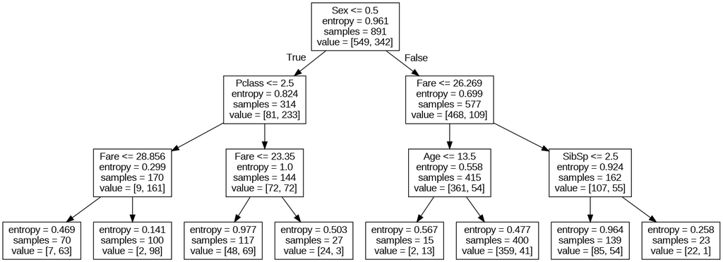

```python
from IPython.display import Image
Image(filename = 'titanic_train.png')
```

**e) Interpret the tree**

What describes the group that had the most deaths by number? Which group had the most survivors?

- The groups that had the most deaths by number is the Male Group and the most group that had the most survivor is the Female group.

## Part 2: Apply the Decision Tree Model

### Step 1: Import and Prepare the Data

**a) Import the data.**

```python
Testing = pd.read_csv('/content/drive/MyDrive/CPE 019 (Retake)/HOA 4.1/titanic_test.csv')
```

```python
Testing.info()
```

```
<class 'pandas.core.frame.DataFrame'>
RangeIndex: 418 entries, 0 to 417
Data columns (total 11 columns):
 #   Column       Non-Null Count  Dtype
---  ------       --------------  -----
 0   PassengerId  418 non-null    int64
 1   Pclass       418 non-null    int64
 2   Name         418 non-null    object
 3   Sex          418 non-null    object
 4   Age          332 non-null    float64
 5   SibSp        418 non-null    int64
 6   Parch        418 non-null    int64
 7   Ticket       418 non-null    object
 8   Fare         417 non-null    float64
 9   Cabin        91 non-null     object
 10  Embarked     418 non-null    object
dtypes: float64(2), int64(4), object(5)
memory usage: 36.0+ KB
```

```python
Testing.tail()
```

|  | PassengerId | Pclass | Name | Sex | Age | SibSp | Parch | Ticket | Fare | Cabin | Embarked |
| --- | --- | --- | --- | --- | --- | --- | --- | --- | --- | --- | --- |
| 413 | 1305 | 3 | Spector, Mr. Woolf | male | NaN | 0 | 0 | A.5. 3236 | 8.0500 | NaN | S |
| 414 | 1306 | 1 | Oliva y Ocana, Dona. Fermina | female | 39.0 | 0 | 0 | PC 17758 | 108.9000 | C105 | C |
| 415 | 1307 | 3 | Saether, Mr. Simon Sivertsen | male | 38.5 | 0 | 0 | SOTON/O.Q. 3101262 | 7.2500 | NaN | S |
| 416 | 1308 | 3 | Ware, Mr. Frederick | male | NaN | 0 | 0 | 359309 | 8.0500 | NaN | S |
| 417 | 1309 | 3 | Peter, Master. Michael J | male | NaN | 1 | 1 | 2668 | 22.3583 | NaN | C |

How many records are in the data set?

- The data has 418 records with some missing values

```python
Testing['Sex'] = Testing['Sex'].apply(lambda x: 1 if x == 'male' else 0)
```

**c) Replace the missing age values with the mean of the ages**

```python
Testing['Age'] = Testing['Age'].fillna(Testing['Age'].mean())
```

**d) Verify that the values have been replaced.**

```python
Testing.head(10)
```

|  | PassengerId | Pclass | Name | Sex | Age | SibSp | Parch | Ticket | Fare | Cabin | Embarked |
| --- | --- | --- | --- | --- | --- | --- | --- | --- | --- | --- | --- |
| 0 | 892 | 3 | Kelly, Mr. James | 1 | 34.5 | 0 | 0 | 330911 | 7.8292 | NaN | Q |
| 1 | 893 | 3 | Wilkes, Mrs. James (Ellen Needs) | 0 | 47.0 | 1 | 0 | 363272 | 7.0000 | NaN | S |
| 2 | 894 | 2 | Myles, Mr. Thomas Francis | 1 | 62.0 | 0 | 0 | 240276 | 9.6875 | NaN | Q |
| 3 | 895 | 3 | Wirz, Mr. Albert | 1 | 27.0 | 0 | 0 | 315154 | 8.6625 | NaN | S |
| 4 | 896 | 3 | Hirvonen, Mrs. Alexander (Helga E Lindqvist) | 0 | 22.0 | 1 | 1 | 3101298 | 12.2875 | NaN | S |
| 5 | 897 | 3 | Svensson, Mr. Johan Cervin | 1 | 14.0 | 0 | 0 | 7538 | 9.2250 | NaN | S |
| 6 | 898 | 3 | Connolly, Miss. Kate | 0 | 30.0 | 0 | 0 | 330972 | 7.6292 | NaN | Q |
| 7 | 899 | 2 | Caldwell, Mr. Albert Francis | 1 | 26.0 | 1 | 1 | 248738 | 29.0000 | NaN | S |
| 8 | 900 | 3 | Abrahim, Mrs. Joseph (Sophie Halaut Easu) | 0 | 18.0 | 0 | 0 | 2657 | 7.2292 | NaN | C |
| 9 | 901 | 3 | Davies, Mr. John Samuel | 1 | 21.0 | 2 | 0 | A/4 48871 | 24.1500 | NaN | S |

```python
Testing['Fare'] = Testing['Fare'].apply(lambda x: 0 if pd.isnull(x) else x)
Testing['Cabin'] = Testing['Cabin'].apply(lambda x: 0 if pd.isnull(x) else x)
```

```python
Testing
```

|  | PassengerId | Pclass | Name | Sex | Age | SibSp | Parch | Ticket | Fare | Cabin | Embarked |
| --- | --- | --- | --- | --- | --- | --- | --- | --- | --- | --- | --- |
| 0 | 892 | 3 | Kelly, Mr. James | 1 | 34.50000 | 0 | 0 | 330911 | 7.8292 | 0 | Q |
| 1 | 893 | 3 | Wilkes, Mrs. James (Ellen Needs) | 0 | 47.00000 | 1 | 0 | 363272 | 7.0000 | 0 | S |
| 2 | 894 | 2 | Myles, Mr. Thomas Francis | 1 | 62.00000 | 0 | 0 | 240276 | 9.6875 | 0 | Q |
| 3 | 895 | 3 | Wirz, Mr. Albert | 1 | 27.00000 | 0 | 0 | 315154 | 8.6625 | 0 | S |
| 4 | 896 | 3 | Hirvonen, Mrs. Alexander (Helga E Lindqvist) | 0 | 22.00000 | 1 | 1 | 3101298 | 12.2875 | 0 | S |
| ... | ... | ... | ... | ... | ... | ... | ... | ... | ... | ... | ... |
| 413 | 1305 | 3 | Spector, Mr. Woolf | 1 | 30.27259 | 0 | 0 | A.5. 3236 | 8.0500 | 0 | S |
| 414 | 1306 | 1 | Oliva y Ocana, Dona. Fermina | 0 | 39.00000 | 0 | 0 | PC 17758 | 108.9000 | C105 | C |
| 415 | 1307 | 3 | Saether, Mr. Simon Sivertsen | 1 | 38.50000 | 0 | 0 | SOTON/O.Q. 3101262 | 7.2500 | 0 | S |
| 416 | 1308 | 3 | Ware, Mr. Frederick | 1 | 30.27259 | 0 | 0 | 359309 | 8.0500 | 0 | S |
| 417 | 1309 | 3 | Peter, Master. Michael J | 1 | 30.27259 | 1 | 1 | 2668 | 22.3583 | 0 | C |

418 rows × 11 columns

### Step 2: Label the testing dataset

**a) Create the array of input variables from the testing data set.**

```python
X_input = Testing[list(columns)].values
```

**b) Apply the model to the testing data set.**

```python
TargetLabels = clf_Train.predict(X_input)
TargetLabels = pd.DataFrame({'Est_Survival':TargetLabels, 'Name':Testing['Name']})
```

**c) Evaluate the accuracy of the estimated labels**

```python
AllData = pd.read_csv("/content/drive/MyDrive/CPE 019 (Retake)/HOA 4.1/titanic_all.csv")
TestingResults = pd.merge(TargetLabels, AllData[['Name', 'Survived']], on = ['Name'])
acc = np.sum(TestingResults['Est_Survival'] == TestingResults['Survived']) / float(len(TestingResults))
print(acc)
```

```
0.7682619647355163
```

## Part 3: Evaluate the Decision Tree Model

### Step 1: Import the data

```python
All_data = pd.read_csv("/content/drive/MyDrive/CPE 019 (Retake)/HOA 4.1/titanic_all.csv", usecols=['Survived','Pclass',
'Gender','Age','SibSp','Fare'])
```

```python
All_data.info()
```

```
<class 'pandas.core.frame.DataFrame'>
RangeIndex: 1308 entries, 0 to 1307
Data columns (total 6 columns):
 #   Column    Non-Null Count  Dtype
---  ------    --------------  -----
 0   Survived  1308 non-null   int64
 1   Pclass    1308 non-null   int64
 2   Gender    1308 non-null   object
 3   Age       1045 non-null   float64
 4   SibSp     1308 non-null   int64
 5   Fare      1308 non-null   float64
dtypes: float64(2), int64(3), object(1)
memory usage: 61.4+ KB
```

How many records are in the data set?

- The Data Set has 1308 records

Which important variables(s) are missing values and how many are missing?

- The only variable that has a missing values is the variable Age